# Part 1

#### Look at the chapter on interactive graphics and, specifically, the code to display a subject's MRICloud data as a sunburst plot

```python
# Import

import pandas as pd
import numpy as np
import matplotlib as mpl
import matplotlib.pyplot as plt
import plotly.express as px
import seaborn as sns
```

```python
df = pd.read_csv("https://raw.githubusercontent.com/smart-stats/ds4bio_book/main/book/assetts/kirby21AllLevels.csv").drop(['Unnamed: 0'], axis = 1)
```

```python
df.head()
```

|  | rawid | roi | volume | min | max | mean | std | type | level | id | icv | tbv |
| --- | --- | --- | --- | --- | --- | --- | --- | --- | --- | --- | --- | --- |
| 0 | kirby127a_3_1_ax.img | Telencephalon_L | 531111 | 0.0 | 374.0 | 128.3013 | 51.8593 | 1 | 1 | 127 | 1378295 | 1268519 |
| 1 | kirby127a_3_1_ax.img | Telencephalon_R | 543404 | 0.0 | 300.0 | 135.0683 | 53.6471 | 1 | 1 | 127 | 1378295 | 1268519 |
| 2 | kirby127a_3_1_ax.img | Diencephalon_L | 9683 | 15.0 | 295.0 | 193.5488 | 32.2733 | 1 | 1 | 127 | 1378295 | 1268519 |
| 3 | kirby127a_3_1_ax.img | Diencephalon_R | 9678 | 10.0 | 335.0 | 193.7051 | 32.7869 | 1 | 1 | 127 | 1378295 | 1268519 |
| 4 | kirby127a_3_1_ax.img | Mesencephalon | 10268 | 55.0 | 307.0 | 230.8583 | 29.2249 | 1 | 1 | 127 | 1378295 | 1268519 |

```python
## load in the hierarchy information
url = "https://raw.githubusercontent.com/bcaffo/MRIcloudT1volumetrics/master/inst/extdata/multilevel_lookup_table.txt"
multilevel_lookup = pd.read_csv(url, sep = "\t").drop(['Level5'], axis = 1)
multilevel_lookup = multilevel_lookup.rename(columns = {
    "modify"   : "roi",
    "modify.1" : "level4",
    "modify.2" : "level3",
    "modify.3" : "level2",
    "modify.4" : "level1"})
multilevel_lookup = multilevel_lookup[['roi', 'level4', 'level3', 'level2', 'level1']]
multilevel_lookup.head()
```

|  | roi | level4 | level3 | level2 | level1 |
| --- | --- | --- | --- | --- | --- |
| 0 | SFG_L | SFG_L | Frontal_L | CerebralCortex_L | Telencephalon_L |
| 1 | SFG_R | SFG_R | Frontal_R | CerebralCortex_R | Telencephalon_R |
| 2 | SFG_PFC_L | SFG_L | Frontal_L | CerebralCortex_L | Telencephalon_L |
| 3 | SFG_PFC_R | SFG_R | Frontal_R | CerebralCortex_R | Telencephalon_R |
| 4 | SFG_pole_L | SFG_L | Frontal_L | CerebralCortex_L | Telencephalon_L |

```python
## Now load in the subject data
id = 127
subjectData = pd.read_csv("https://raw.githubusercontent.com/smart-stats/ds4bio_book/main/book/assetts/kirby21AllLevels.csv")
subjectData = subjectData.loc[(subjectData.type == 1) & (subjectData.level == 5) & (subjectData.id == id)]
subjectData = subjectData[['roi', 'volume']]
## Merge the subject data with the multilevel data
subjectData = pd.merge(subjectData, multilevel_lookup, on = "roi")
subjectData = subjectData.assign(icv = "ICV")
subjectData = subjectData.assign(comp = subjectData.volume / np.sum(subjectData.volume))
subjectData.head()
```

|  | roi | volume | level4 | level3 | level2 | level1 | icv | comp |
| --- | --- | --- | --- | --- | --- | --- | --- | --- |
| 0 | SFG_L | 12926 | SFG_L | Frontal_L | CerebralCortex_L | Telencephalon_L | ICV | 0.009350 |
| 1 | SFG_R | 10050 | SFG_R | Frontal_R | CerebralCortex_R | Telencephalon_R | ICV | 0.007270 |
| 2 | SFG_PFC_L | 12783 | SFG_L | Frontal_L | CerebralCortex_L | Telencephalon_L | ICV | 0.009247 |
| 3 | SFG_PFC_R | 11507 | SFG_R | Frontal_R | CerebralCortex_R | Telencephalon_R | ICV | 0.008324 |
| 4 | SFG_pole_L | 3078 | SFG_L | Frontal_L | CerebralCortex_L | Telencephalon_L | ICV | 0.002227 |

```python
fig = px.sunburst(subjectData, path=['icv', 'level1', 'level2', 'level3', 'level4', 'roi'],
                  values='comp', width=600, height=600)
fig.show()
```

[interactive chart not shown]

#### Display this subject's data as a Sankey diagram.

```python
import plotly.graph_objects as go
```

```python
no_dict = dict()
label_list = list()

n = 0

for i in range(1,5):
    col = 'level'+str(i)

    for j in subjectData[col].unique():
        label_list.append(j)
        no_dict[j] = n
        n += 1
```

```python
source_list = list()
target_list = list()
value_list = list()

for i in range(1,4):

    start = 'level'+str(i)
    end = 'level'+str(i+1)

    for j in subjectData.index:
        s = no_dict[subjectData.loc[j][start]]
        t = no_dict[subjectData.loc[j][end]]
        v = subjectData.loc[j]['comp']

        source_list.append(s)
        target_list.append(t)
        value_list.append(v)
```

```python
fig = go.Figure(data=[go.Sankey(
    node = dict(
      pad =2,
      thickness = 10,
      line = dict(color = "black", width = 0.5),
      label = label_list,
      color = "blue"
    ),
    link = dict(
      source = source_list,
      target = target_list,
      value = value_list
  ))])

fig.update_layout(font_size=8)
fig.show()
```

[interactive chart not shown]

#### Display as many levels as you can for type = 1, starting from the intracranial volume. Put this in a file called hw4.ipynb.

# Part 2

Create a simple webpage containing this graphic and host it on github pages. -Do not- host this off of your assignment repo from github classroom, since this is not public. Instead, you'll have to create a new public repo from your regular github account and add this file. Put the link to your live web page in a markdown cell of your hw4.ipynb file. Note, an easy way to create a webpage with this graphic is to export an ipynb as an html file.

# Part 3

Create the opioid sqlite database from https://smart-stats.github.io/ds4bio_book/book/_build/html/sqlite.html. However, only go to the step where the csv files are read into the database. Then exit sqlite and you should have a file opioid.db that has the data. Next, read the three tables into pandas dataframes and do the data wrangling from the sqlite chapter directly in pandas. Add the python code to your hw4.ipynb file.

```python
#I did via sqlite3
```

# Part 4

Create an interactive scatter plot of average number of opiod pills by year plot using plotly. See the example here. Don't do the intervals (little vertical lines), only the points. Add your plot to an html file with your repo for your Sanky diagram and host it publicly. Put a link to your hosted file in a markdown cell of your hw4.ipynb file. Note, an easy way to create a webpage with this graphic is to export an ipynb as an html file. Reminder, the html files need to be in your own repository (since your github classroom repo is private). However, your hw4.ipynb file should be turned in via your githubclassroom repo.

```python
df1 = pd.read_csv("https://raw.githubusercontent.com/opencasestudies/ocs-bp-opioid-rural-urban/master/data/simpler_import/county_pop_arcos.csv")
df2 = pd.read_csv("https://raw.githubusercontent.com/opencasestudies/ocs-bp-opioid-rural-urban/master/data/simpler_import/land_area.csv")
df3 = pd.read_csv("https://raw.githubusercontent.com/opencasestudies/ocs-bp-opioid-rural-urban/master/data/simpler_import/county_annual.csv", delimiter=',', encoding="utf-8-sig")

df3.head()
```

|  | Unnamed: 0 | BUYER_COUNTY | BUYER_STATE | year | count | DOSAGE_UNIT | countyfips |
| --- | --- | --- | --- | --- | --- | --- | --- |
| 0 | 1 | ABBEVILLE | SC | 2006 | 877 | 363620.0 | 45001.0 |
| 1 | 2 | ABBEVILLE | SC | 2007 | 908 | 402940.0 | 45001.0 |
| 2 | 3 | ABBEVILLE | SC | 2008 | 871 | 424590.0 | 45001.0 |
| 3 | 4 | ABBEVILLE | SC | 2009 | 930 | 467230.0 | 45001.0 |
| 4 | 5 | ABBEVILLE | SC | 2010 | 1197 | 539280.0 | 45001.0 |

```python
df3.rename(columns={"year":"year_df3"})
```

|  | Unnamed: 0 | BUYER_COUNTY | BUYER_STATE | year_df3 | count | DOSAGE_UNIT | countyfips |
| --- | --- | --- | --- | --- | --- | --- | --- |
| 0 | 1 | ABBEVILLE | SC | 2006 | 877 | 363620.0 | 45001.0 |
| 1 | 2 | ABBEVILLE | SC | 2007 | 908 | 402940.0 | 45001.0 |
| 2 | 3 | ABBEVILLE | SC | 2008 | 871 | 424590.0 | 45001.0 |
| 3 | 4 | ABBEVILLE | SC | 2009 | 930 | 467230.0 | 45001.0 |
| 4 | 5 | ABBEVILLE | SC | 2010 | 1197 | 539280.0 | 45001.0 |
| ... | ... | ... | ... | ... | ... | ... | ... |
| 27753 | 27754 | NaN | NV | 2007 | 447 | 200600.0 | NaN |
| 27754 | 27755 | NaN | NV | 2008 | 5 | 2200.0 | NaN |
| 27755 | 27756 | NaN | OH | 2006 | 23 | 5100.0 | NaN |
| 27756 | 27757 | NaN | PR | 2006 | 10 | 17800.0 | NaN |
| 27757 | 27758 | NaN | PR | 2007 | 2 | 1300.0 | NaN |

27758 rows × 7 columns

```python
def get_avg(yr):
    return df3[yr]
```

```python
df['avg_dose'] = df['year'].apply(lambda x: get_avg(x))
df
```

[output not shown]

```python
for i in df3.year():
    avg_dose_year = pd.mean(df3.DOSAGE_UNIT)
print(avg_dose_year)
```

[output not shown]

```python
df4.avg_dose = df3.groupby('year')['DOSAGE_UNIT'].mean()
df4.head()
print(df4)
```

```
year
2006    2.645410e+06
2007    2.992099e+06
2008    3.252162e+06
2009    3.526038e+06
2010    3.783656e+06
2011    4.035583e+06
2012    3.993064e+06
2013    3.861752e+06
2014    3.768738e+06
Name: DOSAGE_UNIT, dtype: float64
```

```python
import plotly.express as px
g = px.scatter(df3, x=df3.year_df3, y=df4.avg_dose)
fig.show()
```

[output not shown]

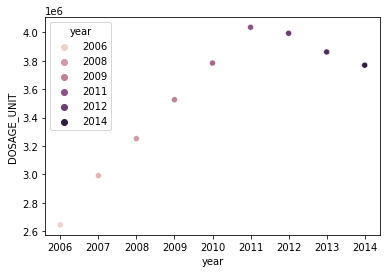

```python
g =sns.scatterplot(x="year", y=df4.avg_dose,
              hue="year",
              data=df4)
```